# Project: Investigate the probability of no-show in medical appointments

## *By Mai Nguyen*

- Introduction
- Data Wrangling
- Exploratory Data Analysis
- Conclusions

## Introduction

> The dataset contains information about patients who have made medical appointments, as well as whether or not they have showed up at the scheduled time. Included in the data are the patients' health conditions, such as having or not diabetes, hypertensions and alcoholism. Other generic characteristics like genders, addresses and ages are also available. In this analysis, we will provide some exploratory visualizations for the correlation between such variables and the probability that the patient did not show up at the appointments. After that, research questions as follows will be explored:
> 1. Is there a relationship between Age and No-show probability?
> 2. Does the average age differ between male and female patients?
> 3. Is there a relationship between hypertension and the show-up/no-show status?

```python
#disable warnings
import warnings
warnings.simplefilter('ignore')
```

```python
# Use this cell to set up import statements for all of the packages that you
#   plan to use.

# Remember to include a 'magic word' so that your visualizations are plotted
#   inline with the notebook. See this page for more:
#   http://ipython.readthedocs.io/en/stable/interactive/magics.html

import pandas as pd
import numpy as np
from scipy import stats
from scipy.stats import ttest_ind
import statsmodels.api as sm
import matplotlib.pyplot as plt
import seaborn as sns

%matplotlib inline
```

## Data Wrangling

### General Properties

```python
# Load data and print out a few lines.
df = pd.read_csv('noshowappointments-kagglev2-may-2016.csv')
df.head()
```

|  | PatientId | AppointmentID | Gender | ScheduledDay | AppointmentDay | Age | Neighbourhood | Scholarship | Hipertension | Diabetes | Alcoholism | Handcap | SMS_received | No-show |
| --- | --- | --- | --- | --- | --- | --- | --- | --- | --- | --- | --- | --- | --- | --- |
| 0 | 2.987250e+13 | 5642903 | F | 2016-04-29T18:38:08Z | 2016-04-29T00:00:00Z | 62 | JARDIM DA PENHA | 0 | 1 | 0 | 0 | 0 | 0 | No |
| 1 | 5.589978e+14 | 5642503 | M | 2016-04-29T16:08:27Z | 2016-04-29T00:00:00Z | 56 | JARDIM DA PENHA | 0 | 0 | 0 | 0 | 0 | 0 | No |
| 2 | 4.262962e+12 | 5642549 | F | 2016-04-29T16:19:04Z | 2016-04-29T00:00:00Z | 62 | MATA DA PRAIA | 0 | 0 | 0 | 0 | 0 | 0 | No |
| 3 | 8.679512e+11 | 5642828 | F | 2016-04-29T17:29:31Z | 2016-04-29T00:00:00Z | 8 | PONTAL DE CAMBURI | 0 | 0 | 0 | 0 | 0 | 0 | No |
| 4 | 8.841186e+12 | 5642494 | F | 2016-04-29T16:07:23Z | 2016-04-29T00:00:00Z | 56 | JARDIM DA PENHA | 0 | 1 | 1 | 0 | 0 | 0 | No |

### Data Cleaning

> We can see that there are typos in the name of some columns, so the first step is to correct these typos. In addition, we transform the 'No-show' column into the 'Status' column, with 'No' indicating that the patient did not show up and 'Yes' indicating the opposite, to make it more intuitive and less confusing.

```python
df.rename(columns={'Hipertension': 'Hypertension', 'Handcap': 'Handicap', 'No-show':'Status'}, inplace=True)
```

```python
df['Status'] = df['Status'].map(dict(Yes='No', No='Yes'))
df.head(5)
```

|  | PatientId | AppointmentID | Gender | ScheduledDay | AppointmentDay | Age | Neighbourhood | Scholarship | Hypertension | Diabetes | Alcoholism | Handicap | SMS_received | Status |
| --- | --- | --- | --- | --- | --- | --- | --- | --- | --- | --- | --- | --- | --- | --- |
| 0 | 2.987250e+13 | 5642903 | F | 2016-04-29T18:38:08Z | 2016-04-29T00:00:00Z | 62 | JARDIM DA PENHA | 0 | 1 | 0 | 0 | 0 | 0 | Yes |
| 1 | 5.589978e+14 | 5642503 | M | 2016-04-29T16:08:27Z | 2016-04-29T00:00:00Z | 56 | JARDIM DA PENHA | 0 | 0 | 0 | 0 | 0 | 0 | Yes |
| 2 | 4.262962e+12 | 5642549 | F | 2016-04-29T16:19:04Z | 2016-04-29T00:00:00Z | 62 | MATA DA PRAIA | 0 | 0 | 0 | 0 | 0 | 0 | Yes |
| 3 | 8.679512e+11 | 5642828 | F | 2016-04-29T17:29:31Z | 2016-04-29T00:00:00Z | 8 | PONTAL DE CAMBURI | 0 | 0 | 0 | 0 | 0 | 0 | Yes |
| 4 | 8.841186e+12 | 5642494 | F | 2016-04-29T16:07:23Z | 2016-04-29T00:00:00Z | 56 | JARDIM DA PENHA | 0 | 1 | 1 | 0 | 0 | 0 | Yes |

> Next, we investigate the data type of each column:

```python
df.info()
```

```
<class 'pandas.core.frame.DataFrame'>
RangeIndex: 110527 entries, 0 to 110526
Data columns (total 14 columns):
PatientId         110527 non-null float64
AppointmentID     110527 non-null int64
Gender            110527 non-null object
ScheduledDay      110527 non-null object
AppointmentDay    110527 non-null object
Age               110527 non-null int64
Neighbourhood     110527 non-null object
Scholarship       110527 non-null int64
Hypertension      110527 non-null int64
Diabetes          110527 non-null int64
Alcoholism        110527 non-null int64
Handicap          110527 non-null int64
SMS_received      110527 non-null int64
Status            110527 non-null object
dtypes: float64(1), int64(8), object(5)
memory usage: 11.8+ MB
```

> It is noticeable that the data of two columns, ScheduledDay and AppointmentDay, is in the form of string. We will convert them into datetime for convenient analysis.

```python
df['ScheduledDay'] = df['ScheduledDay'].apply(pd.to_datetime)
df['AppointmentDay'] = df['AppointmentDay'].apply(pd.to_datetime)
```

> We check the data type of these two columns again to see whether they have been converted successfully:

```python
df.info()
```

```
<class 'pandas.core.frame.DataFrame'>
RangeIndex: 110527 entries, 0 to 110526
Data columns (total 14 columns):
PatientId         110527 non-null float64
AppointmentID     110527 non-null int64
Gender            110527 non-null object
ScheduledDay      110527 non-null datetime64[ns]
AppointmentDay    110527 non-null datetime64[ns]
Age               110527 non-null int64
Neighbourhood     110527 non-null object
Scholarship       110527 non-null int64
Hypertension      110527 non-null int64
Diabetes          110527 non-null int64
Alcoholism        110527 non-null int64
Handicap          110527 non-null int64
SMS_received      110527 non-null int64
Status            110527 non-null object
dtypes: datetime64[ns](2), float64(1), int64(8), object(3)
memory usage: 11.8+ MB
```

```python
df.head()
```

|  | PatientId | AppointmentID | Gender | ScheduledDay | AppointmentDay | Age | Neighbourhood | Scholarship | Hypertension | Diabetes | Alcoholism | Handicap | SMS_received | Status |
| --- | --- | --- | --- | --- | --- | --- | --- | --- | --- | --- | --- | --- | --- | --- |
| 0 | 2.987250e+13 | 5642903 | F | 2016-04-29 18:38:08 | 2016-04-29 | 62 | JARDIM DA PENHA | 0 | 1 | 0 | 0 | 0 | 0 | Yes |
| 1 | 5.589978e+14 | 5642503 | M | 2016-04-29 16:08:27 | 2016-04-29 | 56 | JARDIM DA PENHA | 0 | 0 | 0 | 0 | 0 | 0 | Yes |
| 2 | 4.262962e+12 | 5642549 | F | 2016-04-29 16:19:04 | 2016-04-29 | 62 | MATA DA PRAIA | 0 | 0 | 0 | 0 | 0 | 0 | Yes |
| 3 | 8.679512e+11 | 5642828 | F | 2016-04-29 17:29:31 | 2016-04-29 | 8 | PONTAL DE CAMBURI | 0 | 0 | 0 | 0 | 0 | 0 | Yes |
| 4 | 8.841186e+12 | 5642494 | F | 2016-04-29 16:07:23 | 2016-04-29 | 56 | JARDIM DA PENHA | 0 | 1 | 1 | 0 | 0 | 0 | Yes |

> We create an additional column, which is the difference between the actual appointment date and the previously scheduled day. We name it 'WaitingTime', which is measured by the number of days.

```python
df['WaitingTime'] = (df['AppointmentDay'].dt.date - df['ScheduledDay'].dt.date).dt.days
df.head()
```

|  | PatientId | AppointmentID | Gender | ScheduledDay | AppointmentDay | Age | Neighbourhood | Scholarship | Hypertension | Diabetes | Alcoholism | Handicap | SMS_received | Status | WaitingTime |
| --- | --- | --- | --- | --- | --- | --- | --- | --- | --- | --- | --- | --- | --- | --- | --- |
| 0 | 2.987250e+13 | 5642903 | F | 2016-04-29 18:38:08 | 2016-04-29 | 62 | JARDIM DA PENHA | 0 | 1 | 0 | 0 | 0 | 0 | Yes | 0 |
| 1 | 5.589978e+14 | 5642503 | M | 2016-04-29 16:08:27 | 2016-04-29 | 56 | JARDIM DA PENHA | 0 | 0 | 0 | 0 | 0 | 0 | Yes | 0 |
| 2 | 4.262962e+12 | 5642549 | F | 2016-04-29 16:19:04 | 2016-04-29 | 62 | MATA DA PRAIA | 0 | 0 | 0 | 0 | 0 | 0 | Yes | 0 |
| 3 | 8.679512e+11 | 5642828 | F | 2016-04-29 17:29:31 | 2016-04-29 | 8 | PONTAL DE CAMBURI | 0 | 0 | 0 | 0 | 0 | 0 | Yes | 0 |
| 4 | 8.841186e+12 | 5642494 | F | 2016-04-29 16:07:23 | 2016-04-29 | 56 | JARDIM DA PENHA | 0 | 1 | 1 | 0 | 0 | 0 | Yes | 0 |

> We place the WaitingTime column right after the ScheduledDay and AppointmentDay columns so that the arrangement of the dataset is more intuitive.

```python
cols = list(df.columns.values)
print(cols)
```

```
['PatientId', 'AppointmentID', 'Gender', 'ScheduledDay', 'AppointmentDay', 'Age', 'Neighbourhood', 'Scholarship', 'Hypertension', 'Diabetes', 'Alcoholism', 'Handicap', 'SMS_received', 'Status', 'WaitingTime']
```

```python
df = df[['PatientId', 'AppointmentID', 'Gender', 'ScheduledDay', 'AppointmentDay', 'WaitingTime', 'Age', 'Neighbourhood', 'Scholarship', 'Hypertension', 'Diabetes', 'Alcoholism', 'Handicap', 'SMS_received', 'Status']]
```

> Next, we check for abnormal values, possible outliers as well as null values in the data of each column.

```python
#check for unique values#

print('Gender:',df['Gender'].unique())
print('WaitingTime:',sorted(df['WaitingTime'].unique()))
print('Age:',sorted(df['Age'].unique()))
print('Neighbourhood:',df['Neighbourhood'].unique())
print('Scholarship:',df['Scholarship'].unique())
print('Hypertension:',df['Hypertension'].unique())
print('Diabetes:',df['Diabetes'].unique())
print('Alcoholism:',df['Alcoholism'].unique())
print('Handicap:',df['Handicap'].unique())
print('SMS_received:',df['SMS_received'].unique())
print('Status:',df['Status'].unique())
```

```
Gender: ['F' 'M']
WaitingTime: [-6, -1, 0, 1, 2, 3, 4, 5, 6, 7, 8, 9, 10, 11, 12, 13, 14, 15, 16, 17, 18, 19, 20, 21, 22, 23, 24, 25, 26, 27, 28, 29, 30, 31, 32, 33, 34, 35, 36, 37, 38, 39, 40, 41, 42, 43, 44, 45, 46, 47, 48, 49, 50, 51, 52, 53, 54, 55, 56, 57, 58, 59, 60, 61, 62, 63, 64, 65, 66, 67, 68, 69, 70, 71, …
Age: [-1, 0, 1, 2, 3, 4, 5, 6, 7, 8, 9, 10, 11, 12, 13, 14, 15, 16, 17, 18, 19, 20, 21, 22, 23, 24, 25, 26, 27, 28, 29, 30, 31, 32, 33, 34, 35, 36, 37, 38, 39, 40, 41, 42, 43, 44, 45, 46, 47, 48, 49, 50, 51, 52, 53, 54, 55, 56, 57, 58, 59, 60, 61, 62, 63, 64, 65, 66, 67, 68, 69, 70, 71, 72, 73, 74, …
Neighbourhood: ['JARDIM DA PENHA' 'MATA DA PRAIA' 'PONTAL DE CAMBURI' 'REPÚBLICA'
 'GOIABEIRAS' 'ANDORINHAS' 'CONQUISTA' 'NOVA PALESTINA' 'DA PENHA'
 'TABUAZEIRO' 'BENTO FERREIRA' 'SÃO PEDRO' 'SANTA MARTHA' 'SÃO CRISTÓVÃO'
 'MARUÍPE' 'GRANDE VITÓRIA' 'SÃO BENEDITO' 'ILHA DAS CAIEIRAS'
 'SANTO ANDRÉ' 'SOLON BORGES' 'BONFIM' 'JARDIM CAMBURI' 'MARIA ORTIZ'
 'JABOUR' 'ANTÔNIO HONÓRIO' 'RESISTÊNCIA' 'ILHA DE SANTA MARIA'
 'JUCUTUQUARA' 'MONTE BELO' 'MÁRIO CYPRESTE' 'SANTO ANTÔNIO' 'BELA VISTA'
 'PRAIA DO SUÁ' 'SANTA HELENA' 'ITARARÉ' 'INHANGUETÁ' 'UNIVERSITÁRIO'
 'SÃO JOSÉ' 'REDENÇÃO' 'SANTA CLARA' 'CENTRO' 'PARQUE MOSCOSO' 'DO MOSCOSO'
 'SANTOS DUMONT' 'CARATOÍRA' 'ARIOVALDO FAVALESSA' 'ILHA DO FRADE'
 'GURIGICA' 'JOANA D´ARC' 'CONSOLAÇÃO' 'PRAIA DO CANTO' 'BOA VISTA'
 'MORADA DE CAMBURI' 'SANTA LUÍZA' 'SANTA LÚCIA' 'BARRO VERMELHO'
 'ESTRELINHA' 'FORTE SÃO JOÃO' 'FONTE GRANDE' 'ENSEADA DO SUÁ'
 'SANTOS REIS' 'PIEDADE' 'JESUS DE NAZARETH' 'SANTA TEREZA' 'CRUZAMENTO'
 'ILHA DO PRÍNCIPE' 'ROMÃO' 'COMDUSA' 'SANTA CECÍLIA' 'VILA RUBIM'
 'DE LOURDES' 'DO QUADRO' 'DO CABRAL' 'HORTO' 'SEGURANÇA DO LAR'
 'ILHA DO BOI' 'FRADINHOS' 'NAZARETH' 'AEROPORTO'
 'ILHAS OCEÂNICAS DE TRINDADE' 'PARQUE INDUSTRIAL']
Scholarship: [0 1]
Hypertension: [1 0]
Diabetes: [0 1]
Alcoholism: [0 1]
Handicap: [0 1 2 3 4]
SMS_received: [0 1]
Status: ['Yes' 'No']
```

```python
# check for the number of null values #
print('Gender:', df['Gender'].isnull().sum())
print('WaitingTime:', df['WaitingTime'].isnull().sum())
print('Age:', df['Age'].isnull().sum())
print('Neighbourhood:', df['Neighbourhood'].isnull().sum())
print('Scholarship:', df['Scholarship'].isnull().sum())
print('Hypertension:', df['Hypertension'].isnull().sum())
print('Diabetes:', df['Gender'].isnull().sum())
print('Alcoholism:', df['Alcoholism'].isnull().sum())
print('Handicap:', df['Handicap'].isnull().sum())
print('SMS_received:', df['SMS_received'].isnull().sum())
print('Status:', df['Status'].isnull().sum())
```

```
Gender: 0
WaitingTime: 0
Age: 0
Neighbourhood: 0
Scholarship: 0
Hypertension: 0
Diabetes: 0
Alcoholism: 0
Handicap: 0
SMS_received: 0
Status: 0
```

> - We see that there is no null values.
> - Taking a close look at the unique values of age, we see that there is a value that does not make sense, which is -1. We will remove it from the analysis. In addition, people with age more than 100 can be considered exceptional, so these outliers will also be excluded.

```python
df = df[(df['Age'] >=0) & (df['Age']<=100)]
```

> Now we will check for outliers in WaitingTime column

[figure not shown]

```python
sns.stripplot(data = df, y = 'WaitingTime', jitter = True)
plt.ylabel('Waiting Time (minutes)')
plt.title('Distribution of Waiting Time')
plt.show()
```

> From the above plot, we can see that there are outliers at the value of lower than 0. Waiting time should be more than 0 so we remove these outliers.

```python
df = df[df['WaitingTime'] >=0]
```

## Exploratory Data Analysis

> First, we will plot some visualizations to have an overview at the distribution of data of the variables:

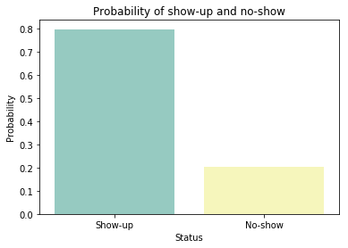

```python
# Presenting the percentage of showing-up/no-show across all situations in the dataset
gs = df['Status'].value_counts()
sns.barplot(x=['Show-up', 'No-show'], y=gs/gs.sum(), palette = 'Set3')
plt.xlabel('Status')
plt.ylabel('Probability')
plt.title('Probability of show-up and no-show')
plt.show()
```

> - We can see that in 80% of the appointments, the patients showed up while in the remaining 20%, the patients did not go to the appointments. Next, we will explore the probability of patients not going to appointments given certain features.
> - There are metric variables (such as age, waiting time) and categorical variables (hypertension, diabetes, alcoholism, handicap) in the data set. We will examine each of these type of variables.

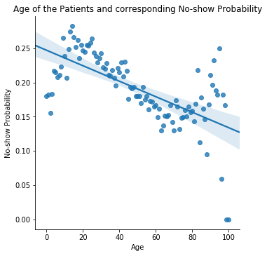

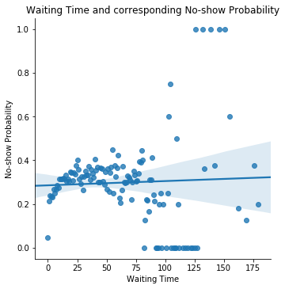

```python
# Exploring the percentage of no-show patients with respect to 2 metric variables: Age and Waiting time

def NoShowProbMetric(group_by):
    dmt = pd.crosstab(index = df[group_by], columns = df['Status']).reset_index()
    dmt['NoshowProb'] = dmt['No'] / (dmt['Yes'] + dmt['No'])
    dmt.columns.name = None
    return dmt[[group_by, 'NoshowProb']]


sns.lmplot(data = NoShowProbMetric('Age'), x = 'Age', y = "NoshowProb")
plt.xlabel('Age')
plt.ylabel('No-show Probability')
plt.title('Age of the Patients and corresponding No-show Probability')
plt.show()

sns.lmplot(data = NoShowProbMetric('WaitingTime'), x = 'WaitingTime', y = "NoshowProb")
plt.xlabel('Waiting Time')
plt.ylabel('No-show Probability')
plt.title ('Waiting Time and corresponding No-show Probability')
plt.show()
```

> From the above two plots, we observe that there is very low correlation between Waiting time and no-show probability, while there appears to be a moderate degree of negative correlation between Age and the percentage of people not showing up in their appointments.

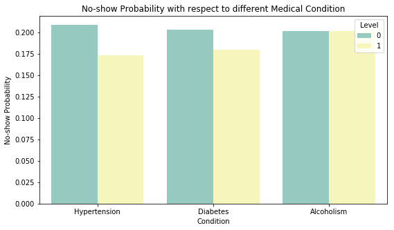

```python
# Exploring the percentage of no-show patients with respect to categorical variables relating to medical history: Hypertension,
# Diabetes, Alcoholism

def NoshowProbCat(group_by):
    rows = []
    for item in group_by:
        for level in df[item].unique():
            row = {'Condition':item}
            Noshow = len(df[(df[item] == level) & (df['Status'] == 'No')])/len(df[df[item] == level])
            row.update({'Level': level, 'Noshowprob': Noshow})
            rows.append(row)
    return pd.DataFrame(rows)

plt.figure(figsize=(9, 5))
sns.barplot(data = NoshowProbCat(['Hypertension', 'Diabetes', 'Alcoholism']), x = 'Condition', y = 'Noshowprob', hue = 'Level', palette = 'Set3')
plt.xlabel('Condition')
plt.ylabel('No-show Probability')
plt.title('No-show Probability with respect to different Medical Condition')
plt.show()
```

> There appears to be no difference between no-show probability between alcoholic and non-alcoholic patients. Meanwhile, in the sample, the group of patients with hypertension shows lower no-show probability than non-hypertension group, and this is similar for diabetes condition. The most noticeble difference is found with respect to hypertension, so it will be examined further in the investigation of the research questions.

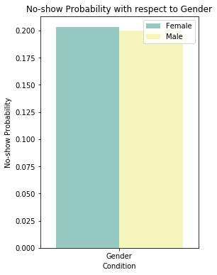

```python
#Exploring the percentage of no-show patients with respect to Gender

plt.figure(figsize=(4, 6))
sns.barplot(data = NoshowProbCat(['Gender']), x = 'Condition', y = 'Noshowprob', hue = ['Female', 'Male'], palette = 'Set3')
plt.ylabel('No-show Probability')
plt.title('No-show Probability with respect to Gender')
plt.show()
```

> We see from the above plot that no-show probabilities between male and female are minimally different.

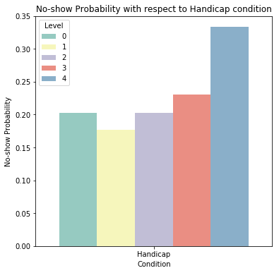

```python
#Exploring the percentage of no-show patients with respect to Handicap condition

plt.figure(figsize=(6, 6))
sns.barplot(data = NoshowProbCat(['Handicap']), x = 'Condition', y = 'Noshowprob', hue = 'Level', palette = 'Set3')
plt.ylabel('No-show Probability')
plt.title('No-show Probability with respect to Handicap condition')
plt.show()
```

> It is noticeable that the group of patients with the highest level of handicap has the highest level of no-show probability.

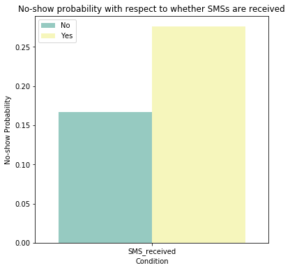

```python
#Exploring the percentage of no-show patients with respect to whether the patients received the reminding SMS or not.

plt.figure(figsize=(6, 6))
sns.barplot(data = NoshowProbCat(['SMS_received']), x = 'Condition', y = 'Noshowprob', hue = ['No', 'Yes'], palette = 'Set3')
plt.ylabel('No-show Probability')
plt.title('No-show probability with respect to whether SMSs are received')
plt.show()
```

> Surprisingly, the percentage of no-show in the group of people receiving an SMS is higher than in the group not receiving an SMS.

Next, we will specify 3 research questions and perform statistical tests to answer these questions. By plotting the data as above, we see that age appears to be a potentially good predictor of no-show probability. Therefore, we come to the first research question as follows:

### Research Question 1: Is there a relationship between Age and No-show probability?

From the plot, we can hypothesize that Age is negatively associated with No-show probability.

```python
# Using OLS regression method to test this hypothesis


X = NoShowProbMetric('Age')['Age'] # X is Age, the independent variable
y = NoShowProbMetric('Age')['NoshowProb'] # y is the probability of no-show, the dependent variable
X = sm.add_constant(X)

model = sm.OLS(y, X).fit()
predictions = model.predict(X)

# Print out the statistics
model.summary()
```

OLS Regression Results

| Dep. Variable: | NoshowProb | R-squared: | 0.430 |
| --- | --- | --- | --- |
| Model: | OLS | Adj. R-squared: | 0.424 |
| Method: | Least Squares | F-statistic: | 74.59 |
| Date: | Mon, 05 Feb 2018 | Prob (F-statistic): | 1.02e-13 |
| Time: | 17:23:39 | Log-Likelihood: | 187.13 |
| No. Observations: | 101 | AIC: | -370.3 |
| Df Residuals: | 99 | BIC: | -365.0 |
| Df Model: | 1 |  |  |
| Covariance Type: | nonrobust |  |  |

|  | coef | std err | t | P>\|t\| | [0.025 | 0.975] |
| --- | --- | --- | --- | --- | --- | --- |
| const | 0.2470 | 0.008 | 32.634 | 0.000 | 0.232 | 0.262 |
| Age | -0.0011 | 0.000 | -8.637 | 0.000 | -0.001 | -0.001 |

| Omnibus: | 17.285 | Durbin-Watson: | 0.972 |
| --- | --- | --- | --- |
| Prob(Omnibus): | 0.000 | Jarque-Bera (JB): | 32.119 |
| Skew: | -0.676 | Prob(JB): | 1.06e-07 |
| Kurtosis: | 5.409 | Cond. No. | 115. |

Next, we further explore another relationship relating to age of the patients. We will investigate whether the average age of female group is different from that of the male group.

### Research Question 2: Does the average age differ between male and female patients?

> In this research question, the independent variable, Gender, is categorical, and the dependent variable, Age, is metric. Therefore, we will perform binary t-test to address this research question

```python
# Use this, and more code cells, to explore your data. Don't forget to add
#   Markdown cells to document your observations and findings.

avg_female = df[df['Gender'] == 'F']['Age'].mean()
avg_male = df[df['Gender'] == 'M']['Age'].mean()
```

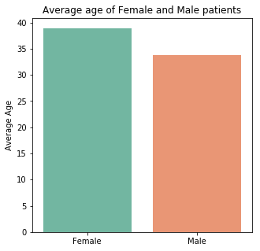

```python
# Barplot illustrating average age of male and female groups

plt.figure(figsize = (5,5))
sns.barplot(x=['Female', 'Male'], y=[avg_female, avg_male], palette = 'Set2')
plt.ylabel('Average Age')
plt.title('Average age of Female and Male patients')
plt.show()
```

> From the above barplot, we see that in the sample, the average age of female patients is higher than male patients. Now we will conduct t-test to see whether this difference also exists in the population.

```python
#Perform to test to investigate whether the two group means are statistically significant

ttest_ind(df[df['Gender'] == 'F']['Age'], df[df['Gender'] == 'M']['Age'])
```

```
Ttest_indResult(statistic=35.548014995533393, pvalue=3.2332808449588542e-275)
```

> The result shows that the p-value < 0.05, so there is a statistically significant difference between the average age between male and female group.

### Research Question 3: Is there a relationship between hypertension and the show-up/no-show status?

To examine this question, we will conduct the Chi-square test of independence since both variables here are nominal.

```python
# Create the contigency table of two variables in the research questions and convert into array form:
hp = pd.crosstab(index = df['Hypertension'], columns = df['Status']).reset_index().as_matrix(columns = ['No', 'Yes'])
hp
```

```
array([[18539, 70175],
       [ 3772, 18028]])
```

```python
# Perform Chi-square test of Independence
stats.chi2_contingency(hp)
```

```
(140.12238496898843,
 2.5029435793950722e-32,
 1,
 array([[ 17909.93045225,  70804.06954775],
        [  4401.06954775,  17398.93045225]]))
```

> In the output above, the first value is the test statistic, the second value is p-value, the third value is the degree of dreedom and the final value is expected frequencies. We observe that the p-value is very small, indicating that there is a significant relationship between hypertension and show-up/no-show status.

## Conclusions

> In this analysis, 3 research questions are addressed. By performing t-test, OLS regression and Chi-square test of independence, we yield three findings:
> - The higher age of the patient is associated with lower probability of no-show. Possible explations for this is that older patients tend to pay more attention to health checks than younger people since high age is normally correlated with the risk of illness. In addition, older people is more likely to suffer from symptoms, aches and pains that need more urgent medical attention, forcing them to show up at appoitments that they have scheduled.
> - The average age of female patients is higher than male patients. This can imply that the health of women is better than that of men, since women appear to face medical problems at a higher age than men. It can be explained by the healthier lifestile and more serious disease prevention of women compared to men.
> - There is an association between whether the patients have hypertension and whether they show up at the appointment. The fact that hypertension requires regular check-ups can explain this finding.

```python
from subprocess import call
call(['python', '-m', 'nbconvert', 'Investigate_a_Dataset.ipynb'])
```

```
0
```